```python
import numpy as np #used for scientific computation
import pandas as pd #used for data mugging and preprocessing
import matplotlib.pyplot as plt #data visualization library
from pandas import DataFrame as show # dataframe is the optimised structure used here to clean and analyse data
import seaborn as sns # stastical visualization library
import squarify #used to make square area plots
%matplotlib inline #used in jupyter notebook for interactive visualizations within notebook
```

```
UsageError: unrecognized arguments: #used in jupyter notebook for interactive visualizations within notebook
```

```python
df = pd.read_csv("C:/Users/kumar/OneDrive/Documents/data science/Startup_funding.csv")
```

```python
df.head(5)
```

|  | SNo | Date | StartupName | IndustryVertical | SubVertical | CityLocation | InvestorsName | InvestmentType | AmountInUSD | Remarks |
| --- | --- | --- | --- | --- | --- | --- | --- | --- | --- | --- |
| 0 | 0 | 01/08/2017 | TouchKin | Technology | Predictive Care Platform | Bangalore | Kae Capital | Private Equity | 1,300,000 | NaN |
| 1 | 1 | 02/08/2017 | Ethinos | Technology | Digital Marketing Agency | Mumbai | Triton Investment Advisors | Private Equity | NaN | NaN |
| 2 | 2 | 02/08/2017 | Leverage Edu | Consumer Internet | Online platform for Higher Education Services | New Delhi | Kashyap Deorah, Anand Sankeshwar, Deepak Jain,... | Seed Funding | NaN | NaN |
| 3 | 3 | 02/08/2017 | Zepo | Consumer Internet | DIY Ecommerce platform | Mumbai | Kunal Shah, LetsVenture, Anupam Mittal, Hetal ... | Seed Funding | 500,000 | NaN |
| 4 | 4 | 02/08/2017 | Click2Clinic | Consumer Internet | healthcare service aggregator | Hyderabad | Narottam Thudi, Shireesh Palle | Seed Funding | 850,000 | NaN |

```python
df.tail(3)
```

[output not shown]

```python
print("Information of total number of non-empty columns")
print("-------------------------------------------------")
print(df.info(null_counts=True))
```

[output not shown]

```python
print('Rows {rows} in total and Columns {columns} in total'.format(rows=df.shape[0],columns=df.shape[1]))
```

```
Rows 3044 in total and Columns 10 in total
```

Cleaning the data

```python
print("Columns and their datatypes")
df.dtypes
```

```
Columns and their datatypes
```

[output not shown]

Representation of missing datas Since we can see that 'remarks' has the higher density of missing data,we can neglect this column Here we can use estimated statistical values of available data of attribute('AmountInUSD') to fill the missing values

```python
print("Frequency count of missing values")
df.apply(lambda X:sum(X.isnull()))
```

```
Frequency count of missing values
```

[output not shown]

Here yellow bars repersent the null values(missing values) x axis represents colums(features) of dataset

[figure not shown]

```python
plt.figure(figsize=(10,5)) #plt is the object of matplot lib and .figure() is used to show or change properties of graphs
sns.heatmap(df.isnull(),cmap='viridis',yticklabels=False,cbar=False)#heatmaps are matrix plots which can visualize data in 2D
plt.show()
```

```python
print("Here we can see in date column error- '.' is there instead of '/'")
df[df['Date']=='12/05.2015']['Date']
```

```
Here we can see in date column error- '.' is there instead of '/'
```

```
2103    12/05.2015
2104    12/05.2015
Name: Date, dtype: object
```

```python
df['AmountInUSD'].head(5)#head(n) displays n rows
```

```
0    1,300,000
1          NaN
2          NaN
3      500,000
4      850,000
Name: AmountInUSD, dtype: object
```

WE CAN FILL THE MISSING NUMERICAL VALUES USING FOLLWING STATISTICAL METHODS-

-BY MODE OF CENTRAL TENDENCY

- BACKWARD FILLING

  -FORWARD FILLING

```python
df['CityLocation']=df['CityLocation'].fillna(value='NotSpecific')
```

```python
df['IndustryVertical']=df['IndustryVertical'].fillna(value='Other')
```

```python
import re#importing regular expressions
def convert_Slash(x):#converts citylocation where multiple citiescentres
    x=x.lower()#converting  whole data to lower case to avoid dublicate entries
    if   re.search('/',x):
        return x.split('/')[0].strip()#converting multiple citycentres to single one
    else :
        return x.strip()# removing extra spaces from left and right to reduce duplicate cities
df['CityLocation']=df['CityLocation'].apply(convert_Slash)
```

```python
newdf=df.copy()#backup cleansed data
del newdf['Remarks']#remaks is deleted to overcome stability in analysis
del newdf['SNo']
```

```python
print('Different categories of Inverstment Type before cleansing and removing duplicacy in categories are as follows- ')
newdf['InvestmentType'].value_counts().index# aggregating frequency count according to categories of investment type
```

```
Different categories of Inverstment Type before cleansing and removing duplicacy in categories are as follows-
```

```
Index(['Seed Funding', 'Private Equity', 'SeedFunding', 'PrivateEquity',
       'Crowd Funding', 'Debt Funding', 'Crowd funding'],
      dtype='object')
```

```python
def rem_err_date(x):#function checks for error in format of date column in funding dataframe
    if re.search('.',x):#data column has formatting errors like '12/052015','13/042015' where backslash (/) is missing or at wrong position
        return x.replace('.','')
    return x

newdf['Date']=newdf['Date'].apply(rem_err_date)#applying user defined funciton to date column using apply() which maps u.d.f to each record of date column
newdf['Date'].replace('12/052015','12/05/2015',inplace=True)
newdf['Date'].replace('15/012015','15/01/2015',inplace=True)
newdf['Date'].replace('22/01//2015','22/01/2015',inplace=True)
newdf['Date'].replace('13/042015','13/04/2015',inplace=True)
newdf['Date']=pd.to_datetime(newdf['Date'],format='%d/%m/%Y')#d/m/y is the format and to_datetime() is used to convert the datatype of date column to "datetime" from string
```

```python
print('processed datatype of Date column')
newdf.dtypes['Date']
```

```
processed datatype of Date column
```

```
dtype('<M8[ns]')
```

```python
def calculate_n_investors(x):#function to calculate record wise number of investors
    if  re.search(',',x) and x!='empty':
        return len(x.split(','))
    elif x!='empty':
        return 1
    else:
        return -1
newdf['numberofinvestors']=newdf['InvestorsName'].replace(np.NaN,'empty').apply(calculate_n_investors)#removing missing investors and replacing with 'empty'
```

```python
n_inv2=newdf

n_inv=newdf['InvestorsName']
n_inv.fillna(value='None',inplace=True)
listed_n_inv=n_inv.apply(lambda x: x.lower().strip().split(','))
investors=[]
for i in listed_n_inv:
    for j in i:
        if(i!='None' or i!=''):
            investors.append(j.strip())
unique_investors=list(set(investors))
```

```python
investors=pd.Series(investors)
unique_investors=pd.Series(unique_investors)
```

```python
investors=list(investors[investors!=''])
unique_investors=list(unique_investors[unique_investors!=''])
```

```python
for i in range(len(unique_investors)):
    for j in range(len(investors)):
        if(re.search(unique_investors[i],investors[j])):
            investors[j]=unique_investors[i]
```

```python
def convert_AmountInUSD(x):
    if re.search(',',x):
        return (x.replace(',',''))
    return x
newdf['AmountInUSD']=newdf[newdf['AmountInUSD'].notnull()]['AmountInUSD'].apply(convert_AmountInUSD).astype('int')
```

```python
newdf['AmountInUSD']=round(newdf['AmountInUSD'].fillna(np.mean(newdf['AmountInUSD'])))
newdf['AmountInUSD']=newdf['AmountInUSD'].astype('int')
```

```python
newdf['InvestmentType'].fillna(method='bfill',inplace=True)#backward filling of null values
```

```python
newdf.iloc[:,[1,2,3,4,6]]=newdf.iloc[:,[1,2,3,4,6]].applymap(lambda x: x.lower().replace(' ','') if pd.notnull(x) is True else x )
```

```python
def check(x):
    if(pd.notnull(x)):
        return x.lower()
newdf.iloc[:,3]=newdf.iloc[:,3].apply(check)
```

analysis of data after cleaning

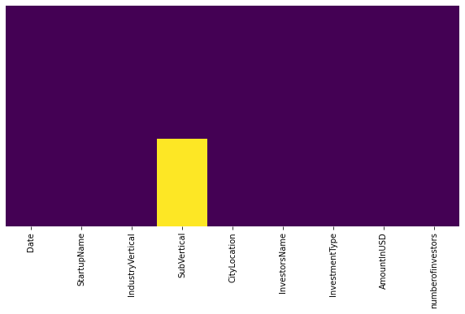

```python
plt.figure(figsize=(10,5))
sns.heatmap(newdf.isnull(),cmap='viridis',yticklabels=False,cbar=False)
plt.show()
```

Removing ambigous records(startup names like flipkart and flipkart.com )

```python
unique_startup_name=list(newdf['StartupName'].unique())
startupname=list(newdf['StartupName'])
```

```python
for i in range(len(unique_startup_name)):
    for j in range(len(startupname)):
        if(re.search(unique_startup_name[i],startupname[j])):
            startupname[j]=unique_startup_name[i]
```

```python
newdf['StartupName']=startupname
```

```python
newdf.head(10)
```

|  | Date | StartupName | IndustryVertical | SubVertical | CityLocation | InvestorsName | InvestmentType | AmountInUSD | numberofinvestors |
| --- | --- | --- | --- | --- | --- | --- | --- | --- | --- |
| 0 | 2017-08-01 | touchkin | technology | predictivecareplatform | bangalore | Kae Capital | privateequity | 1300000 | 1 |
| 1 | 2017-08-02 | ethinos | technology | digitalmarketingagency | mumbai | Triton Investment Advisors | privateequity | 12031073 | 1 |
| 2 | 2017-08-02 | leverageedu | consumerinternet | onlineplatformforhighereducationservices | newdelhi | Kashyap Deorah, Anand Sankeshwar, Deepak Jain,... | seedfunding | 12031073 | 7 |
| 3 | 2017-08-02 | zepo | consumerinternet | diyecommerceplatform | mumbai | Kunal Shah, LetsVenture, Anupam Mittal, Hetal ... | seedfunding | 500000 | 4 |
| 4 | 2017-08-02 | click2clinic | consumerinternet | healthcareserviceaggregator | hyderabad | Narottam Thudi, Shireesh Palle | seedfunding | 850000 | 2 |
| 5 | 2017-07-01 | billionloans | consumerinternet | peertopeerlendingplatform | bangalore | Reliance Corporate Advisory Services Ltd | seedfunding | 1000000 | 1 |
| 6 | 2017-07-03 | ecolibriumenergy | technology | energymanagementsolutionsprovider | ahmedabad | Infuse Ventures, JLL | privateequity | 2600000 | 2 |
| 7 | 2017-07-04 | droom | ecommerce | onlinemarketplaceforautomobiles | gurgaon | Asset Management (Asia) Ltd, Digital Garage Inc | privateequity | 20000000 | 2 |
| 8 | 2017-07-05 | jumbotail | ecommerce | onlinemarketplaceforfoodandgrocery | bangalore | Kalaari Capital, Nexus India Capital Advisors | privateequity | 8500000 | 2 |
| 9 | 2017-07-05 | moglix | ecommerce | b2bmarketplaceforindustrialproducts | noida | International Finance Corporation, Rocketship,... | privateequity | 12000000 | 6 |

```python
newdf.head()
```

|  | Date | StartupName | IndustryVertical | SubVertical | CityLocation | InvestorsName | InvestmentType | AmountInUSD | numberofinvestors |
| --- | --- | --- | --- | --- | --- | --- | --- | --- | --- |
| 0 | 2017-08-01 | touchkin | technology | predictivecareplatform | bangalore | Kae Capital | privateequity | 1300000 | 1 |
| 1 | 2017-08-02 | ethinos | technology | digitalmarketingagency | mumbai | Triton Investment Advisors | privateequity | 12031073 | 1 |
| 2 | 2017-08-02 | leverageedu | consumerinternet | onlineplatformforhighereducationservices | newdelhi | Kashyap Deorah, Anand Sankeshwar, Deepak Jain,... | seedfunding | 12031073 | 7 |
| 3 | 2017-08-02 | zepo | consumerinternet | diyecommerceplatform | mumbai | Kunal Shah, LetsVenture, Anupam Mittal, Hetal ... | seedfunding | 500000 | 4 |
| 4 | 2017-08-02 | click2clinic | consumerinternet | healthcareserviceaggregator | hyderabad | Narottam Thudi, Shireesh Palle | seedfunding | 850000 | 2 |

```python
show(newdf.describe()['AmountInUSD'].astype(int))
```

|  | AmountInUSD |
| --- | --- |
| count | 2372 |
| mean | 12031073 |
| std | 51335545 |
| min | 16000 |
| 25% | 700000 |
| 50% | 7300000 |
| 75% | 12031073 |
| max | 1400000000 |

```python
print(newdf['StartupName'].nunique())
```

```
1792
```

Top 10 startups had most funding

```python
tp10fund=show(newdf.groupby('StartupName')['AmountInUSD'].sum().sort_values(ascending=False))
tp10fund.head(10)
```

| StartupName | AmountInUSD |
| --- | --- |
| paytm | 2.364062e+09 |
| flipkart | 2.259700e+09 |
| ola | 2.001391e+09 |
| snapdeal | 7.000000e+08 |
| oyo | 6.610621e+08 |
| quikr | 2.300000e+08 |
| delhivery | 2.150000e+08 |
| cartrade | 2.120311e+08 |
| foodpanda | 2.100000e+08 |
| shopclues | 2.077000e+08 |

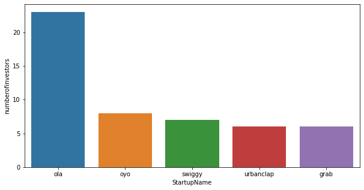

| StartupName | numberofinvestors |
| --- | --- |
| ola | 23 |
| oyo | 8 |
| swiggy | 7 |
| urbanclap | 6 |
| grab | 6 |
| paytm | 6 |
| faircent | 5 |
| jugnoo | 5 |
| nobroker | 5 |
| medinfi | 5 |

```python
cmi=show(newdf.groupby('StartupName')['numberofinvestors'].count().sort_values(ascending=False))
fig=plt.figure(figsize=(10,5))
sns.barplot(y='numberofinvestors',x='StartupName',data=cmi.reset_index().head())
plt.show()
cmi.head(10)
```

Here we can see that kernel density of startups having two and three number of investors is high

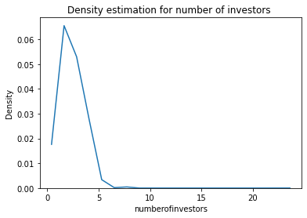

```python
sns.kdeplot(data=cmi.reset_index()['numberofinvestors'],gridsize=20,)#most are  2 or 3 in number
plt.title('Density estimation for number of investors ')
plt.show()
```

is Funding depends on the number of investors?

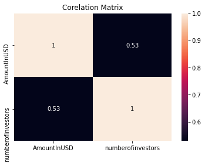

```python
top10=tp10fund.join(cmi)
sns.heatmap(top10.corr(),annot=True)
plt.title('Corelation Matrix')
plt.show()
```

here we can see that there is 50% relation between funding amount and number of investors

```python
# converting all industry vertical entries to lower to avoid category duplication#
newdf['IndustryVertical']=newdf['IndustryVertical'].apply(lambda x:x.lower())
```

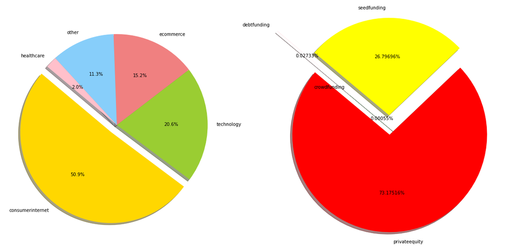

```python
#in which sector there are most startups
d=newdf['IndustryVertical'].value_counts().head(5)
f=newdf.groupby('InvestmentType').sum()['AmountInUSD']
fig,ax=plt.subplots(nrows=1,ncols=2,figsize=(20,10))
labels=[d.index,f.index]
size=[d.values,f.values]
colors = [['gold', 'yellowgreen', 'lightcoral', 'lightskyblue','pink'],['green','pink','red','yellow']]
plt.axis('equal')
explode = ((0.1, 0, 0, 0,0),(-0.5,0.5,0.1,0.1))
ax[0].pie(size[0],explode=explode[0], labels=labels[0], colors=colors[0],
        autopct='%1.1f%%', shadow=True, startangle=140)

ax[1].pie(size[1],explode=explode[1], labels=labels[1], colors=colors[1],autopct='%1.5f%%', shadow=True, startangle=140)
plt.show()
```

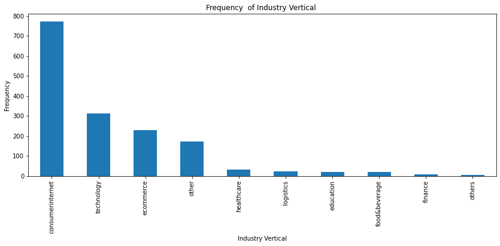

```python
plt.figure(figsize=(14,5))
iv=newdf['IndustryVertical'].value_counts().head(10)
iv.plot.bar()

plt.title('Frequency  of Industry Vertical ')
plt.ylabel('Frequency')
plt.xlabel('Industry Vertical')
plt.show()
```

Time series analysis

```python
dnewdf=newdf.set_index('Date')
dnewdf.head()
```

| Date | StartupName | IndustryVertical | SubVertical | CityLocation | InvestorsName | InvestmentType | AmountInUSD | numberofinvestors |
| --- | --- | --- | --- | --- | --- | --- | --- | --- |
| 2017-08-01 | touchkin | technology | predictivecareplatform | bangalore | Kae Capital | privateequity | 1300000 | 1 |
| 2017-08-02 | ethinos | technology | digitalmarketingagency | mumbai | Triton Investment Advisors | privateequity | 12031073 | 1 |
| 2017-08-02 | leverageedu | consumerinternet | onlineplatformforhighereducationservices | newdelhi | Kashyap Deorah, Anand Sankeshwar, Deepak Jain,... | seedfunding | 12031073 | 7 |
| 2017-08-02 | zepo | consumerinternet | diyecommerceplatform | mumbai | Kunal Shah, LetsVenture, Anupam Mittal, Hetal ... | seedfunding | 500000 | 4 |
| 2017-08-02 | click2clinic | consumerinternet | healthcareserviceaggregator | hyderabad | Narottam Thudi, Shireesh Palle | seedfunding | 850000 | 2 |

```python
print('total number of unique startups funded in 2017 -'+str(len(dnewdf['2017']['StartupName'].unique())))
print('total number of unique startups funded in 2016 -'+str(len(dnewdf['2016']['StartupName'].unique())))
print('total number of unique startups funded in 2015 -'+str(len(dnewdf['2015']['StartupName'].unique())))
```

```
total number of unique startups funded in 2017 -414
total number of unique startups funded in 2016 -889
total number of unique startups funded in 2015 -807
```

Total funding in 2017, Total funding in 2016, total funding in 2015

```python
dnewdf['2017']['AmountInUSD'].sum()
```

```
7747185034
```

```python
dnewdf['2016']['AmountInUSD'].sum()
```

```
8724735319
```

```python
dnewdf['2015']['AmountInUSD'].sum()
```

```
12065784954
```

total funding was most in 2015 and decreased

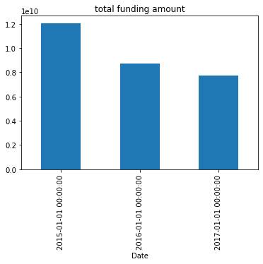

```python
plt.title('total funding amount')
dnewdf.resample('AS')['AmountInUSD'].sum().plot.bar()
plt.show()
```

Total variation of funding amount per month in period of 2015-2017

```python
newdf['year']=newdf['Date'].dt.year
newdf['month']=newdf['Date'].dt.month
```

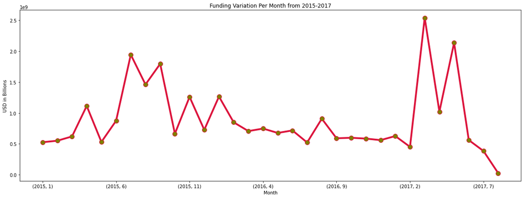

```python
fig =plt.figure(figsize=(20,7))
fig.set_figheight
ts_month = newdf.groupby(['year', 'month']).agg({'AmountInUSD':'sum'})['AmountInUSD']
ts_month.plot(linewidth=4, color='crimson',marker="o", markersize=10, markerfacecolor='olive')
plt.ylabel('USD in Billions')
plt.xlabel('Month');
plt.title('Funding Variation Per Month from 2015-2017')
```

Insights of 2015 Below we can visualize that total funding reached to its peak between the months of june - july and Aug - Sep End week of july was most attracted to investments Quarter 3 was seen as the most funded quarter of 2015

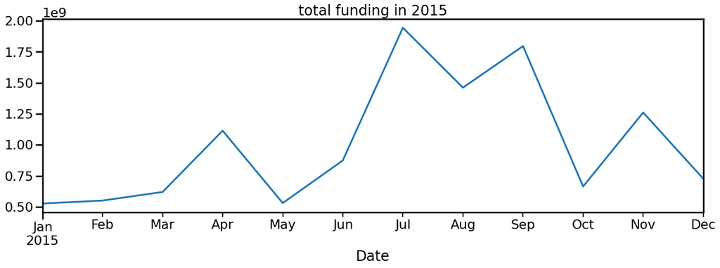

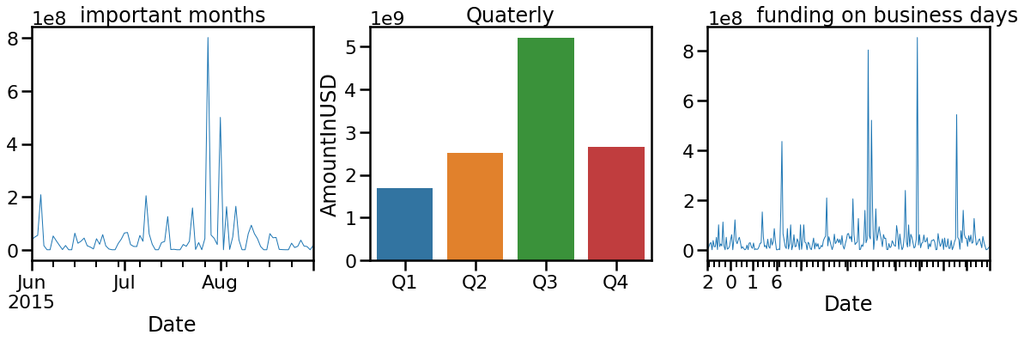

```python
sns.set_context('poster',font_scale=1)
plt.figure(figsize=(20,6))
a=dnewdf['2015'].resample('MS').sum()['AmountInUSD'].plot()
a.set_title('total funding in 2015')
#insights of june-july and augest of 2015
fig2,axes = plt.subplots(nrows=1,ncols=3,figsize=(20,5))
a1=dnewdf['2015-06':'2015-8'].resample('d')['AmountInUSD'].sum().plot(ax=axes[0],lw=1)
a1.set_title('important months')
a2=sns.barplot(data=dnewdf['2015'].resample('Q').sum().reset_index(),y='AmountInUSD',x=['Q1','Q2','Q3','Q4'],ax=axes[1])
a2.set_title('Quaterly')
a3=dnewdf['2015'].resample('B')['AmountInUSD'].sum().plot(ax=axes[2],lw=1)
a3.set_title('            funding on business days')
a3.set_xticklabels('2016')
plt.show()
```

insights of 2016

It seems to be january and augest was the most funding month in 2016¶ A sudden increase is witnessed in the month of july - August

further after september uniform low funding due to demonetization of indian currency

An inverse relation among funding by Quarter

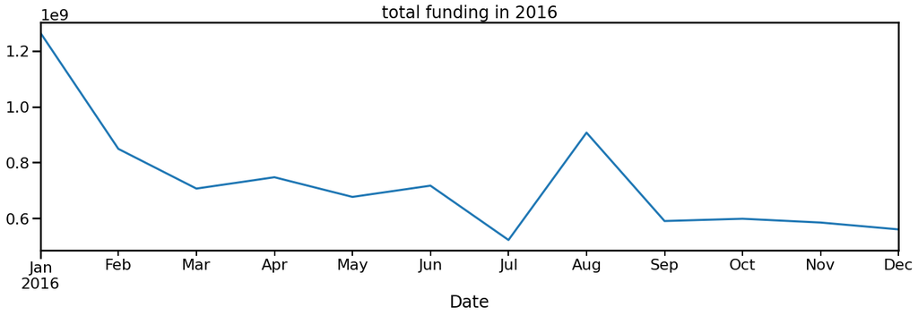

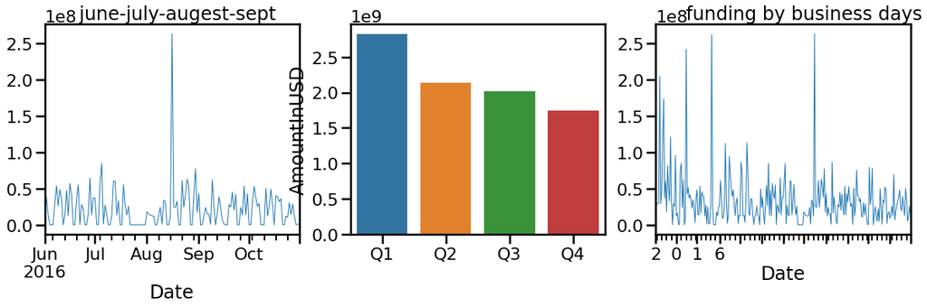

```python
sns.set_context('poster',font_scale=1)


plt.figure(figsize=(22,6))


a=dnewdf['2016'].resample('MS').sum()['AmountInUSD'].plot()
a.set_title('total funding in 2016')
#insights of june-july and augest of 2015

fig2,axes = plt.subplots(nrows=1,ncols=3,figsize=(20,5))

a1=dnewdf['2016-06':'2016-10'].resample('d')['AmountInUSD'].sum().fillna(method='ffill').plot(ax=axes[0],lw=1)
a1.set_title('  june-july-augest-sept')

sns.barplot(data=dnewdf['2016'].resample('Q').sum().reset_index(),y='AmountInUSD',x=['Q1','Q2','Q3','Q4'],ax=axes[1])
a2.set_title('Quaterly')

a3=dnewdf['2016'].resample('B')['AmountInUSD'].sum().plot(ax=axes[2],lw=1)
a3.set_title('       funding by business days')

a3.set_xticklabels('2016')
plt.show()
```

Insights of 2017

Month of March and second Week of May had seen peak funding scenarios Quarter 2 has most funding

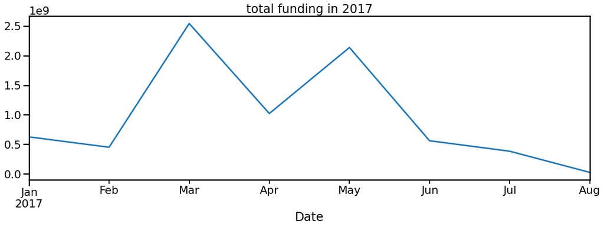

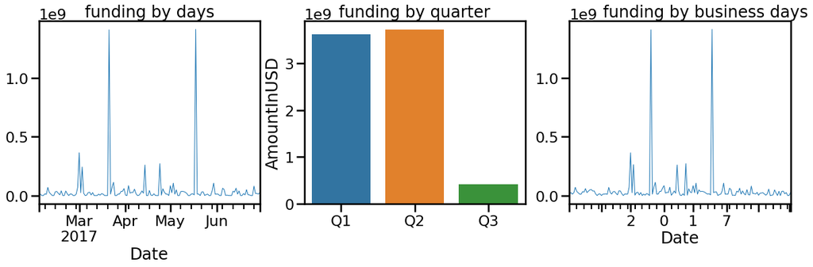

```python
sns.set_context('poster',font_scale=1)


plt.figure(figsize=(20,6))


a=dnewdf['2017'].resample('MS').sum()['AmountInUSD'].plot()
a.set_title('total funding in 2017')
#insights of june-july and augest of 2015

fig2,axes = plt.subplots(nrows=1,ncols=3,figsize=(20,5))
a1=dnewdf['2017-02':'2017-6'].resample('d')['AmountInUSD'].sum().fillna(method='ffill').plot(ax=axes[0],lw=1)
a1.set_title('funding by days')

a2=sns.barplot(data=dnewdf['2017'].resample('Q').sum().reset_index(),y='AmountInUSD',x=['Q1','Q2','Q3'],ax=axes[1])
a2.set_title('funding by quarter')

a3=dnewdf['2017'].resample('B')['AmountInUSD'].sum().plot(ax=axes[2],lw=1)
a3.set_title('          funding by business days')
a3.set_xticklabels('  2017')
plt.show()
```

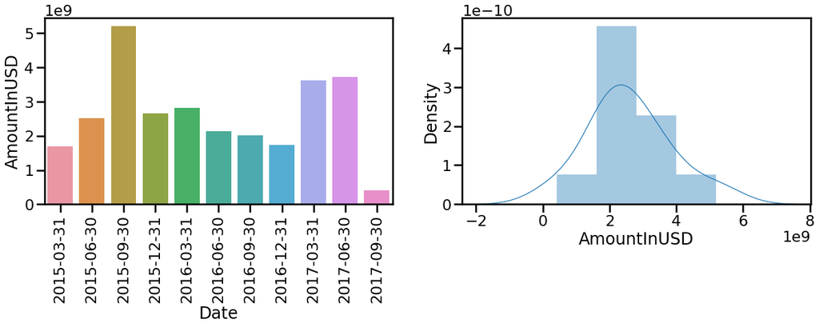

```python
fig,ax=plt.subplots(1,2,figsize=(20,5))

sns.set_context('paper',font_scale=2)
dft=dnewdf.resample('Q').sum()
dft.index=dft.reset_index()['Date'].apply(lambda x: x.date())
a=sns.barplot(data=dft.reset_index(),x='Date',y='AmountInUSD',ax=ax[0])

plt.sca(ax[0])
plt.xticks(rotation=90)
plt.title('')

sns.distplot(dnewdf.resample('q').sum()['AmountInUSD'],ax=ax[1])

plt.show()
```